# Worked Example: Air Quality

Johan Larsson

## Air Quality in New York

As soon as you’re faced with two numeric variables, your first instinct should always be to want to put them on a scatter plot. One such situation could arise with a dataset like the `airquality` dataset, which consists of air quality measurements from New York, in May to September 1973.

The variables in this dataset are

**`Ozone`**

Mean ozone in parts per billion from 1300 to 1500 hours at Roosevelt Island

**`Solar.R`**

Solar radiation in Langleys in the frequency band 4000–7700 Angstroms from 0800 to 1200 hours at Central Park

**`Wind`**

Average wind speed in miles per hour at 0700 and 1000 hours at LaGuardia Airport

**`Temp`**

Maximum daily temperature in degrees Fahrenheit at La Guardia Airport.

**`Day`, `Month`**

Self-explanatory.

Here are the first few rows of the dataset.

```r
head(airquality)
```

```
##   Ozone Solar.R Wind Temp Month Day
## 1    41     190  7.4   67     5   1
## 2    36     118  8.0   72     5   2
## 3    12     149 12.6   74     5   3
## 4    18     313 11.5   62     5   4
## 5    NA      NA 14.3   56     5   5
## 6    28      NA 14.9   66     5   6
```

Let’s begin by just studying how wind affects air pollution (the level of ozone) in the air. Take a minute to consider how you would map the variables to the axes to study this relationship.

Well, our layman intuition tells us that it’s likely that the wind affects air pollution, and not the other way around, so the natural mapping here is to place wind speed on the x axis and ozone on the y axis.

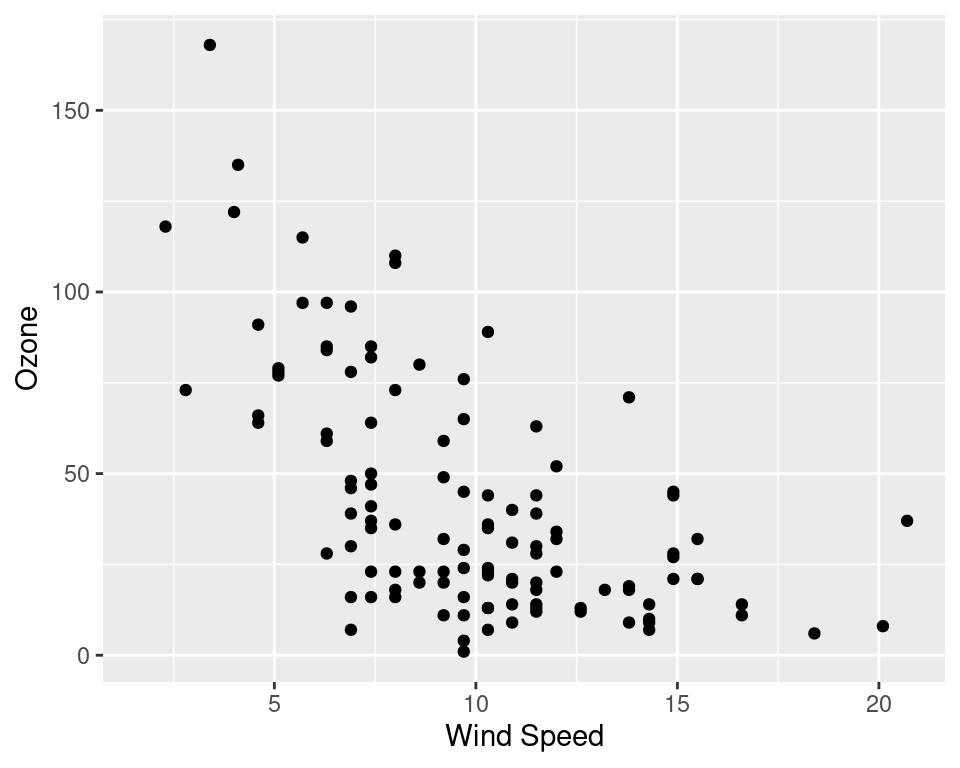

```r
library(tidyverse)

airquality %>%
  ggplot(aes(Wind, Ozone)) +
  geom_point() +
  labs(x = "Wind Speed")
```

There is clearly a strong negative relationship here between wind speed and ozone—with increasing levels of speed, air quality seems to improve. That’s hardly surprising if you think about it. But what kind of relationship is it? Describing it as a linear relationship is not accurate.

The best way to describe this relationship is as an *inverse* relationship. That is, ozone is inversely proportional to wind speed, which is equivalent to saying that the relationship could be described as
$$\text{ozone} = \frac{c}{\text{wind speed}}$$
for some choice of a constant $c$.

Take some time to plot the associations between `Ozone`, `Solar.R`, `Wind`, and `Temp` and try to think about what kind of patterns (if any) it is you see.

### Longitudinal Data

This data is longitudinal in nature so it seems reasonable to want to see how these measures vary across time. First, however, we need to convert the day and month variables into a single variable representing time. Here we use the handy `make_date()` function from the **lubridate** package.

```r
library(lubridate)

airquality2 <-
  airquality %>%
  as_tibble() %>% # tibbles are nicer to work with than data frames
  mutate(Date = make_date("1973", Month, Day))

airquality2
```

```
## # A tibble: 153 x 7
##    Ozone Solar.R  Wind  Temp Month   Day Date
##    <int>   <int> <dbl> <int> <int> <int> <date>
##  1    41     190   7.4    67     5     1 1973-05-01
##  2    36     118   8      72     5     2 1973-05-02
##  3    12     149  12.6    74     5     3 1973-05-03
##  4    18     313  11.5    62     5     4 1973-05-04
##  5    NA      NA  14.3    56     5     5 1973-05-05
##  6    28      NA  14.9    66     5     6 1973-05-06
##  7    23     299   8.6    65     5     7 1973-05-07
##  8    19      99  13.8    59     5     8 1973-05-08
##  9     8      19  20.1    61     5     9 1973-05-09
## 10    NA     194   8.6    69     5    10 1973-05-10
## # … with 143 more rows
```

Now we’re ready to play with the data. The main interest of the dataset is of course air quality, so we want to look at ozone levels across time.

Here is a first attempt. We use the line geom, which is a natural choice for this type of data.

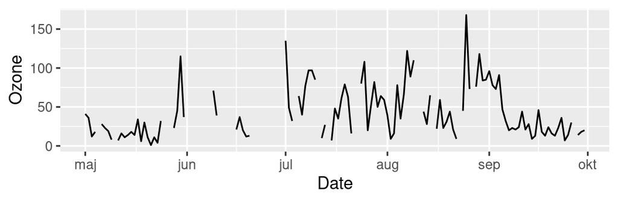

Air quality (ozone levels) in 1973.

```r
p1 <-
  airquality2 %>%
  ggplot(aes(Date, Ozone)) +
  geom_line()

p1
```

The result is possibly not quite as nice as you’d expect. Can you figure out why there are multiple holes in the plot?

The reason is that there are missing values in the data set. This would not per se be a problem for the visualization, weren’t it for the fact that observations that have neighboring observations that are missing also disappear completely from the visualization when we use the line geom.

In this case a better idea is to also use a point geom.

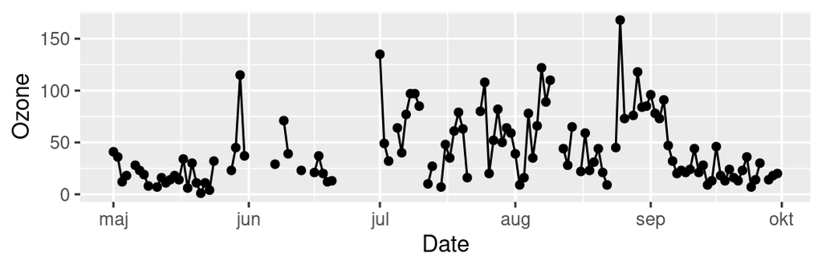

Air quality (ozone levels) in 1973.

```r
p2 <- p1 + geom_point()
p2
```

Despite this missing data, it seems quite clear that the air quality takes a turn for the worse during the summer months.

#### Air Pollution Across the Week

One thing that is currently missing from the visualization but would shed additional light on the relationships is the relationship between air pollution and the type of day, that is, whether it is a weekday or a weekend. A possible solution for this might be to color the weekend days differently, but here we’ll instead use the grid and axis ticks to display this information by specifying scales with `scale_x_date()` and using `"weeks"` as input to the `minor_breaks` argument.

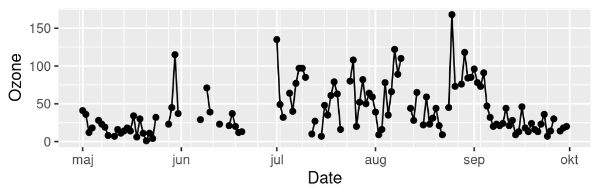

Air quality, in terms of ozone levels, in 1973.

```r
p3 <- p2 + scale_x_date(minor_breaks = "weeks")
p3
```

It’s unfortunately hard to see a clear pattern here, likely because air pollution varies significantly from day to day due to other factors as well. A possible way to solve this is to form a new variable, `Weekday`, in our dataset, which represents the weekday. We use the `wday()` function from lubridate for this purpose.

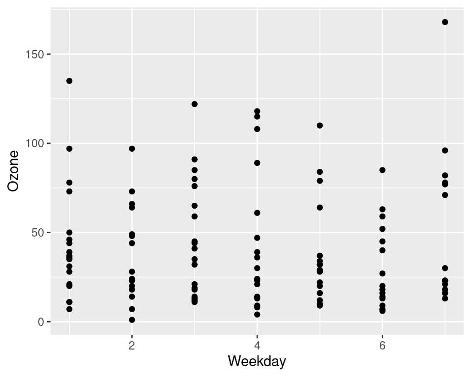

```r
airquality3 <-
  airquality2 %>%
  mutate(Weekday = wday(Date))

airquality3 %>%
  ggplot(aes(Weekday, Ozone)) +
  geom_point()
```

Great, but now the point geom is probably not the best candidate for this job, at least not without jittering and/or opacity. As an alternative, we could instead use boxplots here. To use boxplots here, we need to also convert the `Weekday` variable to a factor variable. To make sure that its order is also kept, we use `as.ordered()` here. We do this directly in the call to `ggplot()`, but note that this means that you need to fix the label of the axis, which will otherwise turn out as `"as.ordered(Weekday)"`.

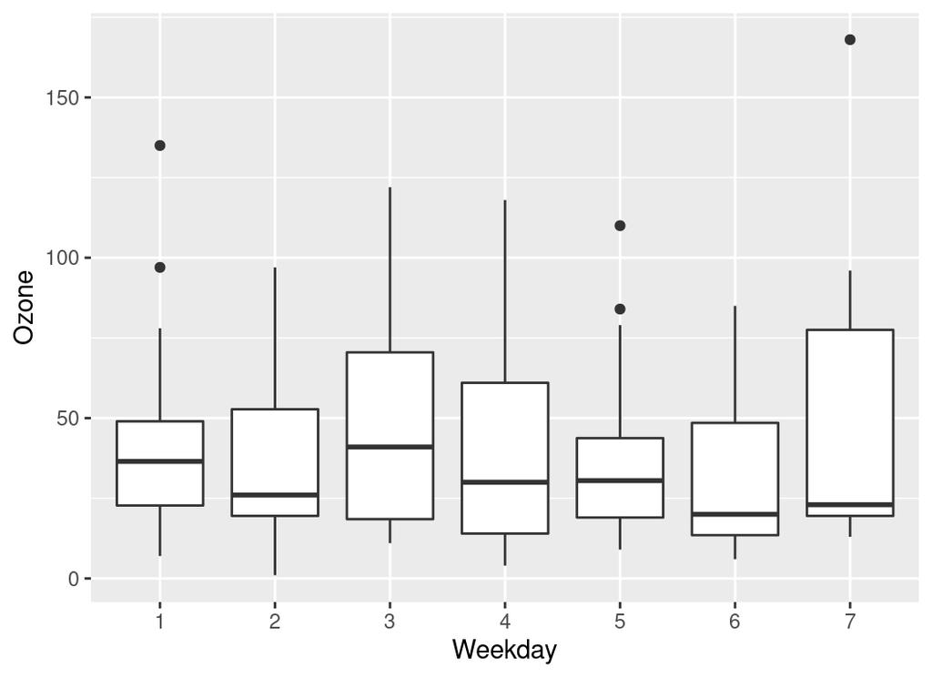

```r
airquality3 %>%
  ggplot(aes(as.ordered(Weekday), Ozone)) +
  geom_boxplot() +
  xlab("Weekday")
```

Take some time to visualize the relationships between time and the other variables in the dataset too.

## Source Code

The source code for this document is available at https://github.com/stat-lu/STAE04/blob/master/worked-example-airquality.Rmd.